# descstat, an R package for computing descriptive statistics

Yves Croissant

2020/11/29

```r
# TODO the default value of total should be set to FALSE
library("descstat")
```

# Frequency tables

Frequency tables are suitable to summarise the univariate distribution of a categorical or an integer series. In `tidyverse`, this task can be performed using the `dplyr::count` function. For example, the `rgp` data set, which is an extract of the French cencus, contains the number of children in households:

```r
rgp %>% count(children)
```

```
## # A tibble: 8 x 2
##   children     n
##      <int> <int>
## 1        0   317
## 2        1   272
## 3        2   260
## 4        3   112
## 5        4    31
## 6        5     6
## 7        6     1
## 8        9     1
```

## Computing a frequency table

The `descstat::freq_table` function performs the same task:

```r
rgp %>% freq_table(children, total = FALSE)
```

```
## # A tibble: 8 x 2
##   children     n
## *    <int> <int>
## 1        0   317
## 2        1   272
## 3        2   260
## 4        3   112
## 5        4    31
## 6        5     6
## 7        6     1
## 8        9     1
```

but it has several further arguments which can improve the results:

- `cols` is a character containing one or several of the following letters:
- `n` for the count or absolute frequencies (the default),
- `f` for the (relative) frequencies,
- `p` for the percentage (ie $f\times 100$). using upper cases letters return the cummulative values
- `total` a boolean, if `TRUE`, a total is returned,
- `max` suitable for a integer series only, an integer which is the maximum value presented in the frequency table, eg `max = 3` create a last line which is `>=3`

The following line use all the possible letters.

```r
rgp %>% freq_table(children, total = FALSE, cols = "nfpNFP")
```

```
## # A tibble: 8 x 7
##   children     n     f     p     N     F     P
## *    <int> <int> <dbl> <dbl> <int> <dbl> <dbl>
## 1        0   317 0.317  31.7   317 0.317  31.7
## 2        1   272 0.272  27.2   589 0.589  58.9
## 3        2   260 0.26   26     849 0.849  84.9
## 4        3   112 0.112  11.2   961 0.961  96.1
## 5        4    31 0.031   3.1   992 0.992  99.2
## 6        5     6 0.006   0.6   998 0.998  99.8
## 7        6     1 0.001   0.1   999 0.999  99.9
## 8        9     1 0.001   0.1  1000 1     100
```

As there are few occurences of families with more than 3 children, we set `max = 3` :

```r
rgp %>% freq_table(children, total = FALSE, max = 3)
```

```
## # A tibble: 4 x 2
##   children     n
##   <chr>    <int>
## 1 0          317
## 2 1          272
## 3 2          260
## 4 >= 3       151
```

## Printing a frequency table

Note that in the printed table, the `children` series is now a character as the last value is now `>=3`. Actually `freq_table` returns an object of class `freq_table` which inherit from the `tbl_df` class. A look at the structure of the object:

```r
rgp %>% freq_table(children, max = 3) %>% str
```

```
## tibble [5 × 2] (S3: freq_table/tbl_df/tbl/data.frame)
##  $ children: num [1:5] 0 1 2 3 Inf
##  $ n       : int [1:5] 317 272 260 151 1000
##  - attr(*, "max")= num 3
##  - attr(*, "total")= logi TRUE
```

indicates that we still have a tibble, with a numeric `children` series for which the last two values equal to 3 (for 3 and more) and `Inf` (for the total). There are two attributes, `max` and `total`, the first one being a numeric and the second one a boolean.

A `pre_print` function is provided with a method for `freq_table` objects. It turns the `children` series in a `character`, with `3` and `Inf` replaced by `>=3` and `Total`. This `pre_print` method is include in the `format` method for `freq_table` which is then passed to the `tbl_df` method:

```r
descstat:::format.freq_table
```

```
## function (x, ..., n = NULL, width = NULL, n_extra = NULL)
## {
##     x <- pre_print(x)
##     class(x) <- setdiff(class(x), "freq_table")
##     format(x, ..., n = n, width = width, n_extra = n_extra)
## }
## <bytecode: 0x55fc60c42d80>
## <environment: namespace:descstat>
```

The `pre_print` function should be used explicitely while using `knitr::kable`, as this function don't use any `format` method:

```r
rgp %>% freq_table(children, max = 3) %>% pre_print %>% knitr::kable()
```

| children | n |
| --- | --- |
| 0 | 317 |
| 1 | 272 |
| 2 | 260 |
| >= 3 | 151 |
| Total | 1000 |

## Ploting a frequency table

The most natural way to plot a frequency table with `ggplot` is to use `geom_col` (or `geom_bar` with `stat = 'identity').

```r
cld <- rgp %>% freq_table(children, cols = "nf", max = 3, total = FALSE)
```

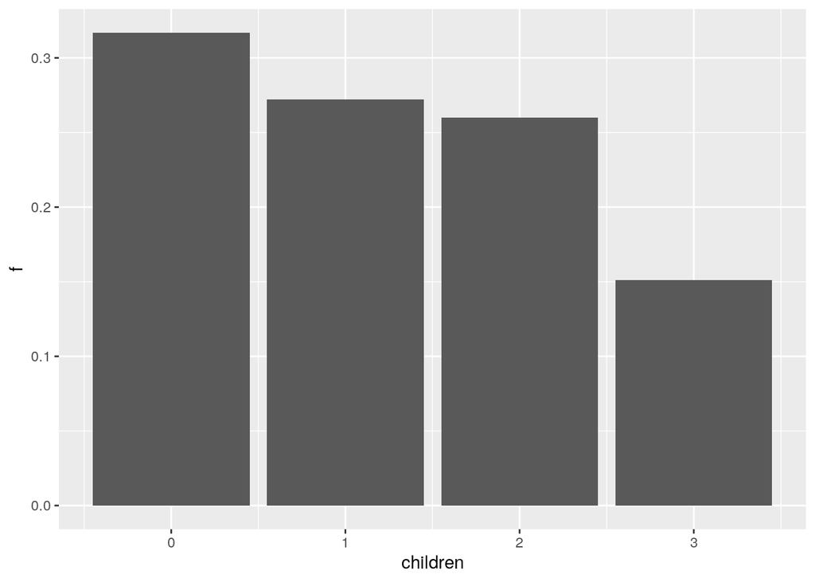

```r
library("ggplot2")
cld %>% ggplot(aes(children, f)) + geom_col()
```

To get more complicated graphics, a `pre_plot` method is provided, with a `plot` argument equal to `banner` or `cummulative`. `plot = banner` plot.

```r
cld %>% pre_plot("f", plot = "banner")
```

[output not shown]

`pre_plot` returns in this case an `ypos` series which indicate the coordinate where to write the label corresponding to the frequencies.

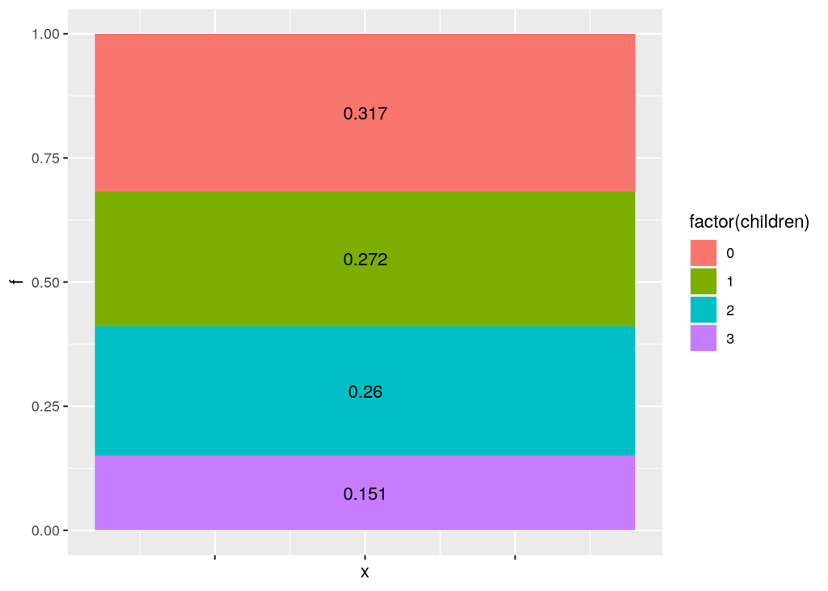

```r
bnp <- cld %>% pre_plot("f", plot = "banner") %>%
    ggplot(aes(x = 2, y = f, fill = factor(children))) +
    geom_col() +
    geom_text(aes(y = ypos, label = f)) +
    scale_x_continuous(label = NULL)
bnp
```

using polar coordinates, we get a pie chart:

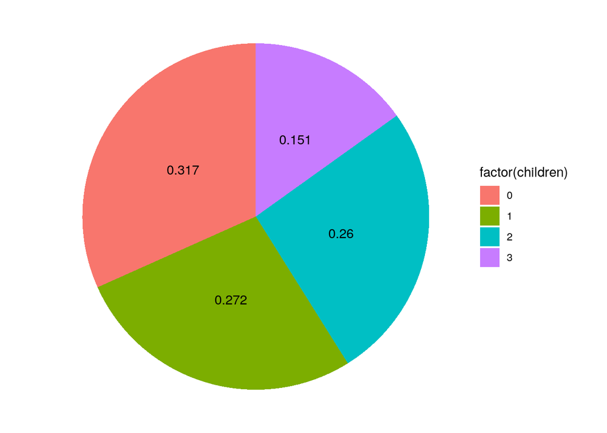

```r
bnp + coord_polar(theta = "y") + theme_void()
```

changing the range of the `x` values, we get a hole in the pie chart which result in the so called donut chart:

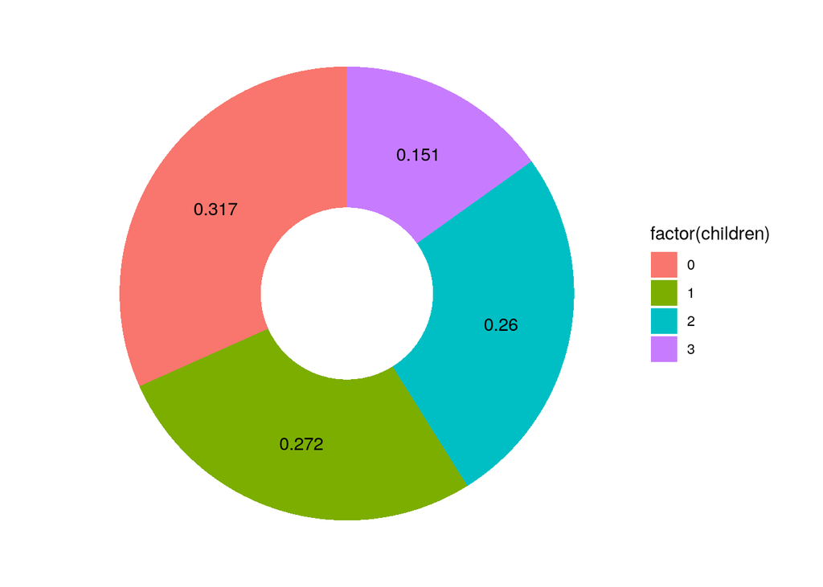

```r
bnp + scale_x_continuous(limits = c(1, 2.5)) +
    coord_polar(theta = "y") + theme_void()
```

The other possible value for the `plot` argument of `pre_plot` is cumulative:

```r
cld <- rgp %>% freq_table(children, "F", max = 5, total = FALSE)
```

```r
cld %>% pre_plot(plot = "cumulative")
```

```
## # A tibble: 12 x 5
##    pos       x  xend     y   yend
##    <chr> <dbl> <dbl> <dbl>  <dbl>
##  1 hor       0    NA 0.317  0.317
##  2 vert     NA    NA 0.317 NA
##  3 hor       1     0 0.589  0.589
##  4 vert      0     0 0.589  0.317
##  5 hor       2     1 0.849  0.849
##  6 vert      1     1 0.849  0.589
##  7 hor       3     2 0.961  0.961
##  8 vert      2     2 0.961  0.849
##  9 hor       4     3 0.992  0.992
## 10 vert      3     3 0.992  0.961
## 11 hor       5     4 1      1
## 12 vert      4     4 1      0.992
```

this returns the 4 series which have the names of the aesthetics that are mandatory for `geom_segment`; `x`, `xend`, `y` and `ydend`. It also returns a `pos` series with which one can draw differently the horizontal (`hor`) and the vertical (`vert`) segments, using for example the `linetype` aesthetic.

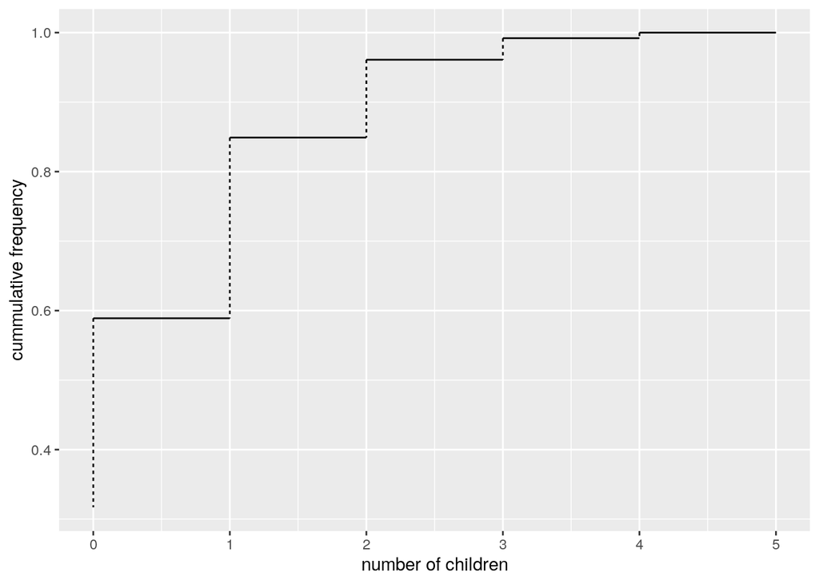

```r
# To do compute automatically F and enables the ploting of N and P
cld %>% pre_plot(plot = "cumulative") %>%
    ggplot() +
    geom_segment(aes(x = x, xend = xend, y = y, yend = yend,
                     linetype = pos)) +
    guides(linetype = FALSE) +
    labs(x = "number of children", y = "cummulative frequency")
```